# Project5 Data Visulaization: Ford GoBike Data

### Bike rides per gender

```python
trip_by_gender_df = df.groupby('member_gender').agg({'bike_id':'count'})
```

```python
trip_by_gender_df['perc'] = (trip_by_gender_df['bike_id']/trip_by_gender_df['bike_id'].sum())*100
```

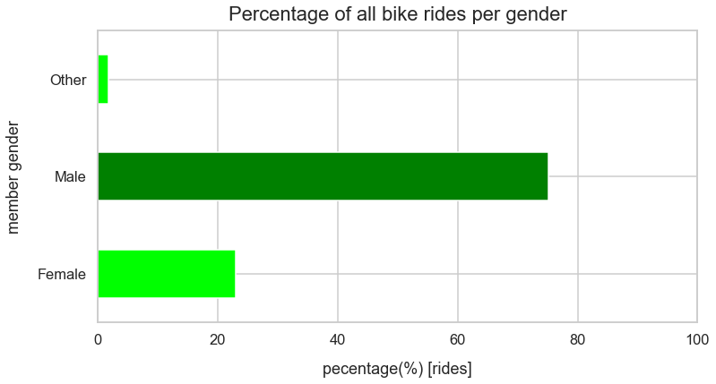

```python
new_color = ['lime', 'green', 'lime']
trip_by_gender_df['perc'].plot(kind='barh', color=new_color, figsize=(12,6))
plt.title('Percentage of all bike rides per gender', fontsize=22, y=1.015)
plt.ylabel('member gender', labelpad=16)
plt.xlabel('pecentage(%) [rides]', labelpad=16)
plt.xticks(rotation=360)
plt.xlim(0,100)
plt.savefig('image03.png');
```

Male took 76% of all bike rides, and female took 22% of them.

### Bike rides per weekday

```python
trip_by_weekday_df = df.groupby('start_time_weekday_abbr').agg({'bike_id':'count'})
```

```python
trip_by_weekday_df['perc'] = (trip_by_weekday_df['bike_id']/trip_by_weekday_df['bike_id'].sum())*100
```

```python
weekday_index = ['Mon', 'Tue', 'Wed', 'Thu', 'Fri', 'Sat', 'Sun']
```

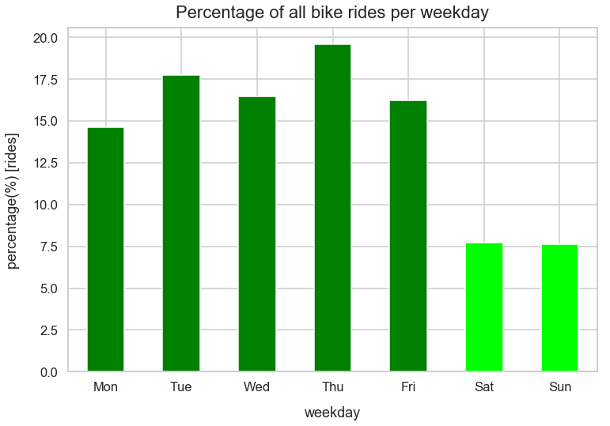

```python
new_color = ['green', 'green', 'green', 'green', 'green', 'lime', 'lime']
trip_by_weekday_df.reindex(weekday_index)['perc'].plot(kind='bar', color=new_color, figsize=(12,8), legend=False)
plt.title('Percentage of all bike rides per weekday', fontsize=22, y=1.015)
plt.xlabel('weekday', labelpad=16)
plt.ylabel('percentage(%) [rides]', labelpad=16)
plt.xticks(rotation=360)
plt.savefig('image04.png');
```

There is huge difference in percentage of all rides during weekdays and weekend. So, majority of people use this service on weekdays.

### Bike rides per hours of the day

```python
trip_by_hour_df = df.groupby('start_time_hour').agg({'bike_id':'count'}).reset_index()
```

```python
trip_by_hour_df['bike_id'] = (trip_by_hour_df['bike_id']/trip_by_hour_df['bike_id'].sum())*100
```

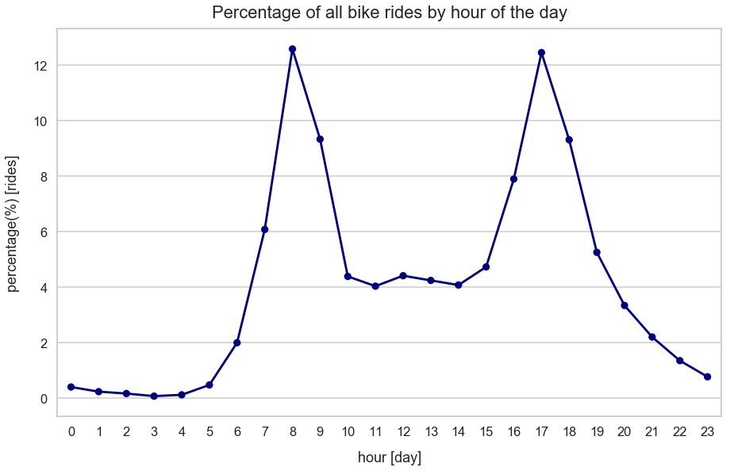

```python
plt.figure(figsize=(15,9))
sns.pointplot(x='start_time_hour', y='bike_id', scale=.7, color='navy', data=trip_by_hour_df)
plt.title('Percentage of all bike rides by hour of the day', fontsize=22, y=1.015)
plt.xlabel('hour [day]', labelpad=16)
plt.ylabel('percentage(%) [rides]', labelpad=16)
plt.savefig('image05.png');
```

8am and 5pm are the peak hours for this service. In other words, majority of people use this service during commute time. Also, people use it when in lunch time as well.